```python
#from IPython.external import mathjax; mathjax.install_mathjax()
```

```python
import numpy as np
import matplotlib.pyplot as plt
%matplotlib inline
plt.rcParams['figure.figsize']=6,6
```

# Motivation for Visible Points

Baake and Hucke say that **Delone Sets** and **Meyer Sets**, describing atomic arrangements, are already "well-understood". To me, these might be pre-requisisites for this paper, or *at least* these topics are mature enough and we can try to experiment with these ourselves.

```python
# how to construct the visible points in the plain?

N = 5
V = np.zeros((2*N+1,2*N+1,2))
x = np.arange(2*N+1)-N
V[x+N,:,0]=x
for k in range(2*N+1):
    V[:,k,1]=x
V[:,:,1]
```

```
array([[-5., -5., -5., -5., -5., -5., -5., -5., -5., -5., -5.],
       [-4., -4., -4., -4., -4., -4., -4., -4., -4., -4., -4.],
       [-3., -3., -3., -3., -3., -3., -3., -3., -3., -3., -3.],
       [-2., -2., -2., -2., -2., -2., -2., -2., -2., -2., -2.],
       [-1., -1., -1., -1., -1., -1., -1., -1., -1., -1., -1.],
       [ 0.,  0.,  0.,  0.,  0.,  0.,  0.,  0.,  0.,  0.,  0.],
       [ 1.,  1.,  1.,  1.,  1.,  1.,  1.,  1.,  1.,  1.,  1.],
       [ 2.,  2.,  2.,  2.,  2.,  2.,  2.,  2.,  2.,  2.,  2.],
       [ 3.,  3.,  3.,  3.,  3.,  3.,  3.,  3.,  3.,  3.,  3.],
       [ 4.,  4.,  4.,  4.,  4.,  4.,  4.,  4.,  4.,  4.,  4.],
       [ 5.,  5.,  5.,  5.,  5.,  5.,  5.,  5.,  5.,  5.,  5.]])
```

```python
V[:,:,0]
```

```
array([[-5., -4., -3., -2., -1.,  0.,  1.,  2.,  3.,  4.,  5.],
       [-5., -4., -3., -2., -1.,  0.,  1.,  2.,  3.,  4.,  5.],
       [-5., -4., -3., -2., -1.,  0.,  1.,  2.,  3.,  4.,  5.],
       [-5., -4., -3., -2., -1.,  0.,  1.,  2.,  3.,  4.,  5.],
       [-5., -4., -3., -2., -1.,  0.,  1.,  2.,  3.,  4.,  5.],
       [-5., -4., -3., -2., -1.,  0.,  1.,  2.,  3.,  4.,  5.],
       [-5., -4., -3., -2., -1.,  0.,  1.,  2.,  3.,  4.,  5.],
       [-5., -4., -3., -2., -1.,  0.,  1.,  2.,  3.,  4.,  5.],
       [-5., -4., -3., -2., -1.,  0.,  1.,  2.,  3.,  4.,  5.],
       [-5., -4., -3., -2., -1.,  0.,  1.,  2.,  3.,  4.,  5.],
       [-5., -4., -3., -2., -1.,  0.,  1.,  2.,  3.,  4.,  5.]])
```

```python
N = 11
V = np.zeros((2*N+1,2*N+1,2))
x = np.arange(2*N+1)-N


xBar, yBar = 0,0

V[x+N,:,0]=x + xBar
for k in range(2*N+1):
    V[:,k,1]=x + yBar

V = np.abs(V)

#print V[:,:,1].astype(int)

#for t in range(30*N):
#    V[:,:,0], V[:,:,1] = np.min(V, axis=2), np.max(V, axis=2)
#    V[:,:,1] = V[:,:,1] - V[:,:,0]

mask = np.where(V[:,:,0] != 0)
c = 0
while len(mask[0]) > 0:

    mask0 = (mask[0], mask[1], 0 + 0*np.arange(mask[0].shape[0]))
    mask1 = (mask[0], mask[1], 1 + 0*np.arange(mask[0].shape[0]))

    V[mask0], V[mask1] = np.min(V[mask], axis=1), np.max(V[mask], axis=1)

    V[mask1] = V[mask1] - V[mask0]

    #V[mask][:,0], V[mask][:,1] = np.min(V[mask], axis=1), np.max(V[mask], axis=1)
    #V[mask][:,1] = V[mask][:,1] - V[mask][:,0]

    mask = np.where(V[:,:,0] != 0)
    c += 1
print "Number of iterations: ", c
print V[:,:,1].astype(int)
#print V[:,:,0].astype(int)
```

```
Number of iterations:  12
[[11  1  1  1  1  1  1  1  1  1  1 11  1  1  1  1  1  1  1  1  1  1 11]
 [ 1 10  1  2  1  2  5  2  1  2  1 10  1  2  1  2  5  2  1  2  1 10  1]
 [ 1  1  9  1  1  3  1  1  3  1  1  9  1  1  3  1  1  3  1  1  9  1  1]
 [ 1  2  1  8  1  2  1  4  1  2  1  8  1  2  1  4  1  2  1  8  1  2  1]
 [ 1  1  1  1  7  1  1  1  1  1  1  7  1  1  1  1  1  1  7  1  1  1  1]
 [ 1  2  3  2  1  6  1  2  3  2  1  6  1  2  3  2  1  6  1  2  3  2  1]
 [ 1  5  1  1  1  1  5  1  1  1  1  5  1  1  1  1  5  1  1  1  1  5  1]
 [ 1  2  1  4  1  2  1  4  1  2  1  4  1  2  1  4  1  2  1  4  1  2  1]
 [ 1  1  3  1  1  3  1  1  3  1  1  3  1  1  3  1  1  3  1  1  3  1  1]
 [ 1  2  1  2  1  2  1  2  1  2  1  2  1  2  1  2  1  2  1  2  1  2  1]
 [ 1  1  1  1  1  1  1  1  1  1  1  1  1  1  1  1  1  1  1  1  1  1  1]
 [11 10  9  8  7  6  5  4  3  2  1  0  1  2  3  4  5  6  7  8  9 10 11]
 [ 1  1  1  1  1  1  1  1  1  1  1  1  1  1  1  1  1  1  1  1  1  1  1]
 [ 1  2  1  2  1  2  1  2  1  2  1  2  1  2  1  2  1  2  1  2  1  2  1]
 [ 1  1  3  1  1  3  1  1  3  1  1  3  1  1  3  1  1  3  1  1  3  1  1]
 [ 1  2  1  4  1  2  1  4  1  2  1  4  1  2  1  4  1  2  1  4  1  2  1]
 [ 1  5  1  1  1  1  5  1  1  1  1  5  1  1  1  1  5  1  1  1  1  5  1]
 [ 1  2  3  2  1  6  1  2  3  2  1  6  1  2  3  2  1  6  1  2  3  2  1]
 [ 1  1  1  1  7  1  1  1  1  1  1  7  1  1  1  1  1  1  7  1  1  1  1]
 [ 1  2  1  8  1  2  1  4  1  2  1  8  1  2  1  4  1  2  1  8  1  2  1]
 [ 1  1  9  1  1  3  1  1  3  1  1  9  1  1  3  1  1  3  1  1  9  1  1]
 [ 1 10  1  2  1  2  5  2  1  2  1 10  1  2  1  2  5  2  1  2  1 10  1]
 [11  1  1  1  1  1  1  1  1  1  1 11  1  1  1  1  1  1  1  1  1  1 11]]
```

```python
def gcd(a,b):
    x,y = abs(a),abs(b)
    while(True):
        if (x > y):
            x,y = y,x
        elif (x == 0):
            return y
        else:
            y = y - x

gcd(15,7)
```

```
1
```

```
(9.0, 51.0)
```

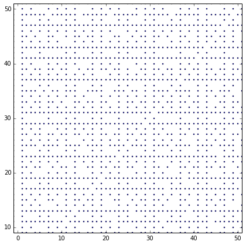

```python
N = 100
V = [(m,n) for m in np.arange(2*N+1)-N for n in np.arange(2*N+1)-N if gcd(m,n) == 1]
V = np.array(V)
plt.plot(V[:,0], V[:,1], 'o', markersize=2)

x0, y0 = 20,30
L = 20
plt.xlim([-1.05*L + x0, 1.05*L + y0])
plt.ylim([-1.05*L + y0, 1.05*L + y0])
#plt.grid(True)
```

# Quadratic Reciprocity Computation

```python
p = 301
P = np.arange(p)

z = np.exp(2.0j*np.pi*P**2/p)
np.sum(z)**2
#plt.plot(z.real, z.imag,  linewidth=0.25)
```

```
(301.00000000003894-5.3589520686818449e-12j)
```

```python
def g(p):
    x = np.arange(p)
    return sum(np.exp(2.0j*np.pi*x**2/p))
p,q,r = 31, 23,13

L = g(p)*g(q)/g(p*q)
np.round(L), np.round(g(p)*g(q)*g(r)*g(p*q*r)/g(p*q)/g(p*r)/g(q*r)), np.around(g(p)*g(q)*g(r)/g(p*q*r)), np.around(g(p*q)*g(q*r)*g(p*r)/g(p*q*r)**2)
```

```
((-1-0j), (1+0j), (-1+0j), (-1+0j))
```

```python
P = [3,5,7,11,13,17,19,23,29,31,37,41,43,47,53,59,61,67,71,73,79,83,89,97]
P = P[5:15]
def L(p,q,r):
    #return np.round(g(p)*g(q)*g(r)*g(p*q*r)/g(p*q)/g(p*r)/g(q*r)).real
    return np.round(np.around(g(p)*g(q)*g(r)/g(p*q*r))).real
print [(p,q,r) for p in P for q in P for r in P if p < q and q < r and L(p,q,r) ==  1]

print [(p,q,r) for p in P for q in P for r in P if p < q and q < r and L(p,q,r) == -1]
```

```
[(17, 19, 29), (17, 19, 37), (17, 19, 41), (17, 19, 53), (17, 23, 29), (17, 23, 37), (17, 23, 41), (17, 23, 53), (17, 29, 31), (17, 29, 37), (17, 29, 41), (17, 29, 43), (17, 29, 47), (17, 29, 53), (17, 31, 37), (17, 31, 41), (17, 31, 53), (17, 37, 41), (17, 37, 43), (17, 37, 47), (17, 37, 53), (17, …
[(17, 19, 23), (17, 19, 31), (17, 19, 43), (17, 19, 47), (17, 23, 31), (17, 23, 43), (17, 23, 47), (17, 31, 43), (17, 31, 47), (17, 43, 47), (19, 23, 29), (19, 23, 31), (19, 23, 37), (19, 23, 41), (19, 23, 43), (19, 23, 47), (19, 23, 53), (19, 29, 31), (19, 29, 43), (19, 29, 47), (19, 31, 37), (19, …
```

# Density of the Visible Points

### **Proposition**

> the visible points are *uniformly discrete* but not *relatively dense*. The natural density is $\frac{6}{\pi^2}$.
> - $V$ contains holes of arbitrary size that repeat lattice periodically
> - given inradius $\rho > 0$, there is sublattice of $\mathbb{Z}^2$ depending on $\rho$ with suitable translate being centers of holes with radius at least $\rho$
> - $GL(2,\mathbb{Z})$ acts transitively on $V$ and one has the partition $\displaystyle \mathbb{Z}^2 = \bigcup_{m \in \mathbb{N}} V$ of $\mathbb{Z}^2$ into $GL(2, \mathbb{Z})$ invariant sets.

### Open Question: Communication of Patterns

> How might the set of visible points be useful to an **engineer** or a **computer scientist** ? An auto mechanic or a girl scout selling cookies does not need to understand the set of visible points. It's not clear who benefits from understanding this set and why.

> In a sense, the set of visible points diescribes anything we might call a **pattern**. I go to church twiwe a week on Friday and Sunday... we get the pattern `oxxxxox` and the fraction `(2,7)` or possibly `(2,5)` depennding on whether you compare `x` and `o` or to the entire interval.

> Even the pattern "once a month" is rather rich in content. Do we mean 12 times per year? That could be `(12,360)` which is **not** visible instead we get `(1,30)` or once every 30 days. But a year has **365** days, so so we really mean `(12,365)` or once every `30.416` days? The difference between these two fractions is quite small $$ \frac{1}{30} - \frac{12}{365} = \frac{1}{2190}$$ Then this number **2190** place a big role in our corrections to the Calendar year. Our error is always on this scale. If we do this 10000 times, there may start to be noticeable problems.

> Poincaré recurrence theorem **Pigeonhole Principle** says our lives much have a very repetitive structure. I show up to work (5,7) days out of the week and have **12** nearby restaurants to choose from only about **3** I actually like. Instead of brining lunch, I ate at Subway **11** times this month, the chicken place **7** times in the month, and less requently ate out at the Thai place **2** times this month. About half the time I eat at subways, but less obviously it takes me about **2** days to get sick of their lack of variety. You will never see me eat Subways **3 days in a row**.

> In this way, the lack of variety forces our behavior into predictible **Markov chains**.

### Open Question: Finding Empty Circles in a Collection of Points

> The proposition says there are arbitrarily large patches of pairs of numbers, none of which are relatively prime, and they form a lattice. We can consturct intervals of numbers none of which are prime, such as $n! + k$ with $k = 0, 1, \dots, n$. This doesn't tell me how to construct pairs of intervals $(a,b) > 0$. In fact, the diagonal definitely *won't* work since $(a,a+1)=1$. Any kind of crazy factorial construction will produce very very large numbers. Instead, a systematic computer search may be in order. Algorithms for finding large empty circles in a random collection of points.

```python
1.0/30 - 12.0/365
```

```
0.0004566210045662128
```

```python
gcd(365-360, 30*365)
```

```
5
```

```python
6*365
```

```
2190
```

# Cut-and-Project Tilings

```
(-1.05, 1.05)
```

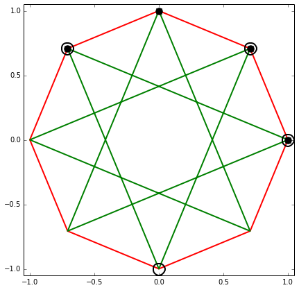

```python
a = np.exp(2.0j*np.pi*np.arange(8+1)/8)
b = a**3

plt.plot(a.real, a.imag, '-', color="r", linewidth=2)
plt.plot(b.real, b.imag, '-', color="g", linewidth=2)

plt.plot(a[:4].real, a[:4].imag, 'o', color="k", markersize=10)
plt.plot(b[:4].real, b[:4].imag, 'o', mfc="none", mec="k", markersize=17, mew=2)

plt.xlim([-1.05, 1.05])
plt.ylim([-1.05, 1.05])
```

```python
?plt.plot
```

```python
def inside(c,u):
    z = np.sum([c[k]*u[k] for k in range(4)])


    #return np.all([(z*np.exp(2.0j*np.pi*k/8)).real < (2 - np.sqrt(2))**-0.5  for k in  range(8)])
    return np.all([(z*np.exp(2.0j*np.pi*k/8)).real < 1.05 for k in  range(8)])
    #return np.abs(z) < 1
```

```
(-15.0, 15.0, -15.0, 15.0)
```

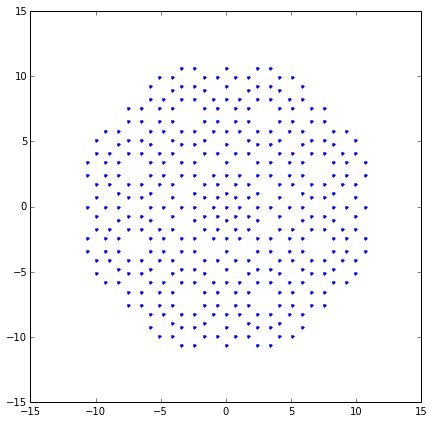

```python
# how to find all the lattice points whose project lie in an octagon or equare?



N = 5

pt = [(i,j,k,l)
      for i in range(-N, N+1)
      for j in range(-N, N+1)
      for k in range(-N, N+1)
      for l in range(-N, N+1)
      if inside(b[:4],(i,j,k,l))]
pt = np.array(pt)

qt = np.sum(pt*a[None,:4], axis=1)
plt.plot(qt.real, qt.imag, '.')
plt.axis("Equal")
```

```
[[-1 -1 -1  0]
 [-1 -1  0  0]
 [-1 -1  0  1]
 [-1  0  0  0]
 [-1  0  0  1]
 [-1  0  1  1]
 [ 0 -1 -1 -1]
 [ 0 -1 -1  0]
 [ 0 -1  0  0]
 [ 0  0 -1 -1]
 [ 0  0 -1  0]
 [ 0  0  0 -1]
 [ 0  0  0  0]
 [ 0  0  0  1]
 [ 0  0  1  0]
 [ 0  0  1  1]
 [ 0  1  0  0]
 [ 0  1  1  0]
 [ 0  1  1  1]
 [ 1  0 -1 -1]
 [ 1  0  0 -1]
 [ 1  0  0  0]
 [ 1  1  0 -1]
 [ 1  1  0  0]
 [ 1  1  1  0]]
```

```
(-3.0, 3.0, -3.0, 3.0)
```

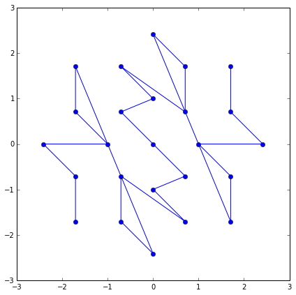

```python
mask = np.where(np.sum(np.abs(pt), axis=1)< 4)

print pt[mask]

qt = np.sum(pt[mask]*a[None,:4], axis=1)
plt.plot(qt.real, qt.imag, '-o')
plt.axis("Equal")
```

```python
def myCircle(z,r):
    dx = 0.01
    return z + r*np.exp(2j*np.pi*np.arange(0,1+dx,dx))
w = myCircle(0,1)
```

```
(-3.0, 3.0, -3.0, 3.0)
```

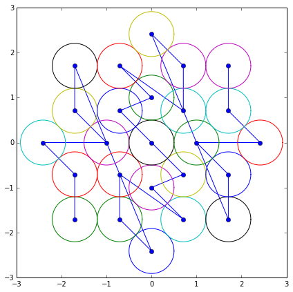

```python
mask = np.where(np.sum(np.abs(pt), axis=1)< 4)

#print pt[mask]

qt = np.sum(pt[mask]*a[None,:4], axis=1)
plt.plot(qt.real, qt.imag, '-o')

for q in qt:
    w = myCircle(q,0.5)
    plt.plot(w.real, w.imag)

plt.axis("Equal")
```

```
(-6.0, 6.0, -6.0, 6.0)
```

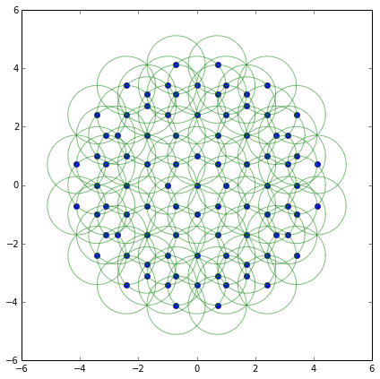

```python
mask = np.where(np.sum(np.abs(pt), axis=1)< 6)

#print pt[mask]

qt = np.sum(pt[mask]*a[None,:4], axis=1)
plt.plot(qt.real, qt.imag, 'o')

for q in qt:
    w = myCircle(q,1)
    plt.plot(w.real, w.imag, 'g',  alpha=0.5)

plt.axis("Equal")
```

```python
?np.any
```

```python
V = [(1,0,0,0),(-1,0,0,0),(0,1,0,0), (0,-1,0,0), (0,0,1,0), (0,0,-1,0), (0,0,0,1),(0,0,0,-1), (0,0,0,0)]


pt = [  [p[k] + v[k] for k in range(4)] for p in pt for v in V if inside([p[k] + v[k] for k in range(4)], b[:4])]

pt = np.array(pt)
```

[output not shown]

```python
([1,2] in [[1,2,3],[3,4,5]])
```

```
False
```

```python
pt
```

```
array([[-8, -8, -4,  2],
       [-7, -7, -4,  2],
       [-7, -8, -5,  2],
       ...,
       [ 8,  9,  4, -2],
       [ 8,  8,  4, -3],
       [ 8,  8,  4, -2]])
```

```
(-10.0, 10.0, -10.0, 10.0)
```

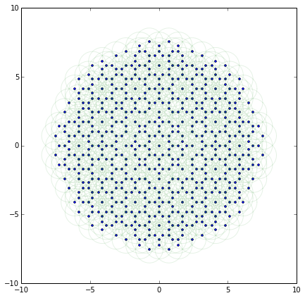

```python
mask = np.where(np.sum(np.abs(pt), axis=1)< 10)
qt = np.sum(pt[mask]*a[None,:4], axis=1)
#qt = np.sum(pt*a[None,:4], axis=1)

plt.plot(qt.real, qt.imag, 'o', markersize=3)

#for x in qt:
#    for y in qt:
#        if(np.abs(x-y) < 1.05 and np.abs(x-y) > 0.95):
#            plt.plot([x.real, y.real], [x.imag, y.imag], 'b')

for q in qt:
    w = myCircle(q,1)
    plt.plot(w.real, w.imag, 'g',  alpha=0.1)

plt.axis("Equal")
```

```python
?np.any
```

```python
V = [(1,0,0,0),(-1,0,0,0),(0,1,0,0), (0,-1,0,0), (0,0,1,0), (0,0,-1,0), (0,0,0,1),(0,0,0,-1)]

pt = [(0,0,0,0)]

for t in range(6):
    #Q = []
    for v in V:
        for p in pt:
            q = np.array([p[k] + v[k] for k in range(4)])
            if inside(q,b[:4]):
                if not np.any(np.all((pt == q), axis=1)):
                    #Q += [q]
                    pt = np.vstack((pt, [q]))
    #pt = np.vstack((pt, Q))
            #print pt.shape[0],
    print pt.shape
#print pt
```

```
(27, 4)
(57, 4)
(131, 4)
(219, 4)
(343, 4)
(453, 4)
```

```
(-15.0, 15.0, -15.0, 15.0)
```

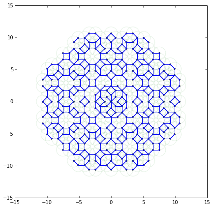

```python
#mask = np.where(np.sum(np.abs(pt), axis=1)< 18)
#qt = np.sum(pt[mask]*a[None,:4], axis=1)
qt = np.sum(pt*a[None,:4], axis=1)

plt.plot(qt.real, qt.imag, 'o', markersize=3)

for x in qt:
    for y in qt:
        if(np.abs(x-y) < 1.05 and np.abs(x-y) > 0.95):
            plt.plot([x.real, y.real], [x.imag, y.imag], 'b')

for q in qt:
    w = myCircle(q,1)
    plt.plot(w.real, w.imag, 'g',  alpha=0.1)

plt.axis("Equal")
```

```python
pt[:,3]
```

```
array([ 3,  3,  4,  4,  5,  5,  5,  5,  6,  6,  6,  7,  7,  7,  8,  8,  8,
        1,  2,  2,  3,  3,  4,  4,  4,  5,  5,  6,  6,  6,  7,  8,  8,  8,
        0,  0,  1,  1,  2,  2,  2,  3,  3,  3,  4,  4,  4,  5,  5,  5,  5,
        6,  6,  7,  7,  7,  8,  8,  8, -2, -1, -1,  0,  0,  1,  0,  1,  1,
        2,  1,  2,  3,  3,  3,  4,  3,  4,  4,  5,  5,  6,  5,  6,  6,  7,
        6,  7,  8,  8,  8,  8, -3, -2, -2, -1, -1, -1,  0,  0,  0,  0,  1,
        1,  2,  2,  2,  3,  3,  4,  4,  4,  5,  5,  5,  6,  6,  6,  7,  7,
        7,  8,  8, -4, -3, -3, -2, -2, -2, -1, -1, -1,  0,  0,  0,  1,  1,
        1,  2,  2,  3,  3,  3,  4,  4,  5,  5,  5,  5,  6,  6,  6,  7,  7,
        8,  8, -5, -4, -4, -3, -3, -3, -2, -2, -1, -1, -1,  0,  0,  1,  1,
        1,  2,  2,  2,  3,  3,  4,  4,  4,  5,  5,  6,  6,  6,  7,  7, -5,
       -5, -4, -4, -4, -3, -3, -3, -2, -2, -2, -1, -1,  0,  0,  0,  0,  1,
        1,  1,  2,  2,  2,  3,  3,  3,  4,  4,  5,  5,  5,  5,  6,  6,  7,
       -6, -5, -6, -5, -4, -5, -4, -4, -3, -4, -3, -3, -2, -1, -2, -1, -1,
        0, -1,  0,  1,  0,  1,  1,  2,  1,  2,  3,  3,  4,  3,  4,  4,  5,
        4,  5,  6,  5,  6, -7, -6, -6, -5, -5, -5, -5, -4, -4, -3, -3, -3,
       -2, -2, -2, -1, -1, -1,  0,  0,  0,  0,  1,  1,  2,  2,  2,  3,  3,
        3,  4,  4,  4,  5,  5, -7, -7, -6, -6, -6, -5, -5, -4, -4, -4, -3,
       -3, -2, -2, -2, -1, -1, -1,  0,  0,  1,  1,  1,  2,  2,  3,  3,  3,
        4,  4,  5, -8, -8, -7, -7, -6, -6, -6, -5, -5, -5, -5, -4, -4, -3,
       -3, -3, -2, -2, -1, -1, -1,  0,  0,  0,  1,  1,  1,  2,  2,  2,  3,
        3,  4, -8, -8, -7, -7, -7, -6, -6, -6, -5, -5, -5, -4, -4, -4, -3,
       -3, -2, -2, -2, -1, -1,  0,  0,  0,  0,  1,  1,  1,  2,  2,  3, -8,
       -8, -8, -8, -7, -6, -7, -6, -6, -5, -6, -5, -5, -4, -4, -3, -4, -3,
       -3, -3, -2, -1, -2, -1, -1,  0, -1,  0,  0,  1,  1,  2, -8, -8, -8,
       -7, -7, -7, -6, -6, -5, -5, -5, -5, -4, -4, -4, -3, -3, -3, -2, -2,
       -2, -1, -1,  0,  0, -8, -8, -8, -7, -6, -6, -6, -5, -5, -4, -4, -4,
       -3, -3, -2, -2, -1, -8, -8, -8, -7, -7, -7, -6, -6, -6, -5, -5, -5,
       -5, -4, -4, -3, -3])
```

# Chair Subsitution Tilings

```python
?np.complex128
```

```
(0.0, 2.0, 0.0, 2.0)
```

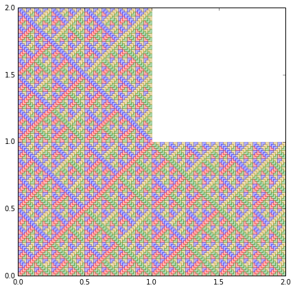

```python
L = np.array([0, 2, 2+1j, 1+1j, 1+2j, 2j, 0])

#plt.fill(L.real, L.imag, alpha=0.2)

F = [lambda x: 0.5*x, lambda x: 0.5*(x + 1 + 1j), lambda x: 0.5*(1j*x + 4),lambda x: 0.5*(-1j*x + 4j)]

#M = [0.5*L, 0.5*(L + 1 + 1j), 0.5*(1j*L + 4), 0.5*(-1j*L + 4j)]

M = [L]

#M = [F[k](L) for k in range(4)]

for t in range(6):
    M = [F[k](m) for k in range(4) for m in M]

#M = [F[k](m) for k in range(4) for m in M]

color = ""
for m in M:
    z = (m[3]-m[0])/np.abs(m[3]-m[0])*np.sqrt(2)
    if z == 1+1j:
        color = "red"
    if z == 1-1j:
        color = "blue"
    if z == -1+1j:
        color = "green"
    if z == -1-1j:
        color = "#BB8800"
    plt.fill(m.real, m.imag, alpha=0.3, color = color)

plt.axis("Equal")

#plt.xlim([0.25,0.75])
#plt.ylim([0.25,0.75])
```

# Substitution Amman Beenker (inconclusive)

```
(0.0, 5.0, 0.0, 7.0)
```

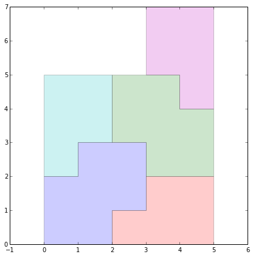

```python
A = np.array([0, 2, 2+1j, 3 + 1j, 3+3j, 1+3j, 1+2j, 2j, 0])

B = np.array([0, 2, 2+3j, 1+3j, 1+2j, 2j, 0])


M = [A, 1j*A + 5 + 2j, A + 4 + 4j, -1*B + 2 + 5j, B + 5 + 2j, 1j*B.conjugate() + 2 + 5j, -1j*B.conjugate() + 5 + 2j]

M = [A, 1j*A + 5 + 2j, -1j*B.conjugate() + 5 + 2j, -1*B + 2 + 5j, B.conjugate() + 3 + 7j]

for m in M:
    plt.fill(m.real, m.imag, alpha=0.2)

plt.axis("Equal")
```

```python
# substitution rule with letters.
# SEE: "Representation of Ammann-Beenker Tilings by an Automaton" Komatsu, Nomakuchi, Sakamoto, Tokitou

x = "r"

for t in range(10):
    x = x.replace("r", "s").replace("R", "RrR").replace("s","R")

sum([1 for t in x if t == "R"])*1.0/len(x), np.sqrt(2)/2
```

```
(0.7071067499256616, 0.70710678118654757)
```

```
(-2.0, 2.0, -2.0, 2.0)
```

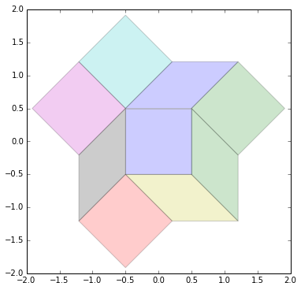

```python
a = np.exp(2j*np.pi*1.0/8)
g = 1 + np.sqrt(2)

A = np.array([0, a, a+a**2, a**2, 0])
A = A - np.average(A[:-1])
B = np.array([0, 1, 1+1j, 1j, 0])
B = B - np.average(B[:-1])

#M = [1j*A, A + 0.5*(1 + g*1j) , a*B+ 0.5*(1+a), B + 0.5*(a**3 + 1j), B - 0.5*(a**3 + 1j), -1*a*B- 0.5*(1+a), A - 0.5*(1 + g*1j) ]

M = [B, a*B + 0.5*g +  0.5j, a*B - 0.5j*g - 0.5,
     a*B + 0.5j*g - 0.5, a*B - 0.5*g + 0.5j, 1j*A - 0.5j - 0.5*a**3,
     A - 0.5- 0.5*a, 1j*A.conjugate()+ 0.5j+ 0.5*a, A.conjugate() + 0.5 - 0.5*a**3]
for m in M:
    plt.fill(m.real, m.imag, alpha=0.2)

plt.axis("Equal")
```

# TetraGrid

Wikipedia points to Beenker's paper (a spin-off of de Brujin's "algebraic" approach, written about 10 years after Ammann's construction.

de Brujin's paper is confusing, and Beenker's paper allows me to get the confusing parts. Pentagrid patterns generate only some of the possible tilings.

**Peter Speh and Tamara Broderick** told me Quantum Mechanics is glorified Fourier Analysis. *Does it follow conversely, that **take a Fourier Analysis, and glorify it into Quantum Mechanics**?*

```python
e = np.exp(2.0j*np.pi/8)
g = np.random.random(4)
g
```

```
array([ 0.42921366,  0.84099325,  0.70184898,  0.19000298])
```

```python
a = lambda z: np.ceil((z*e**(-1*0)).real + g[0])
b = lambda z: np.ceil((z*e**(-1*1)).real + g[1])
c = lambda z: np.ceil((z*e**(-1*2)).real + g[2])
d = lambda z: np.ceil((z*e**(-1*3)).real + g[3])

K = [a,b,c,d]
```

```python
def intersection(a, theta, b, phi):
    return 1j*(-a*np.exp(1j*phi) + b*np.exp(1j*theta))/np.sin(phi - theta)

def inter(a, theta, b, phi):
    return 1j*(-a*np.exp(1j*phi) + b*np.exp(1j*theta))/np.sin(phi - theta)
```

```python
inter(4 , np.pi/4, -4, 3*np.pi/4)
```

```
(5.6568542494923797-4.4408920985006262e-16j)
```

```python
def f(k):
    return np.sum([k[t]*e**t for t in range(4)])

def F(z):
    return np.array([K[t](z) for t in range(4)]).astype(int)
```

```python
theta = np.pi*np.arange(5)/4



x = np.zeros((4,4))
x[np.arange(4), np.arange(4)]=1
```

```
(1, 0) (2, 0) (2, 1) (3, 0) (3, 1) (3, 2)
```

```
(-5, 10)
```

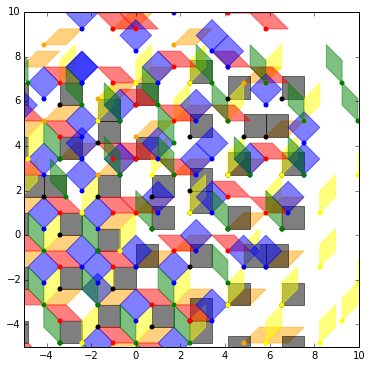

```python
L = 3
#g = np.random.random(4)

color = [["orange"],  ["black", "yellow"], ["red", "blue", "green"] ]

for a in range(4):
    for b in range(a):
        print (a,b),

        pt = [F(inter(m + g[a], theta[a], n + g[b], theta[b])) for m in range(-L,L+1) for n in range(-L,L+1)]

        for p in pt:
            rh = np.array([f(z) for z in [
                p+0*x[a]+0*x[b],
                p+1*x[a]+0*x[b],
                p+1*x[a]+1*x[b],
                p+0*x[a]+1*x[b],
                p+0*x[a]+0*x[b]]
            ])
            plt.fill(rh.real, rh.imag, alpha=0.5, color=color[a-1][b])
        plt.plot([f(p).real for p in pt], [f(p).imag for p in pt], 'o', color=color[a-1][b], markersize=5, mec="None")

plt.axis("Equal")

plt.xlim([-5,10])
plt.ylim([-5,10])
```

```python
np.ceil(-0.5)
```

```
-0.0
```

# Consistency Check -- one vertex

```python
g = [0,0,0,0]
g = np.random.random(4)

# note the minus sign
a = lambda z: np.ceil((z*e**(-1*0)).real - g[0])
b = lambda z: np.ceil((z*e**(-1*1)).real - g[1])
c = lambda z: np.ceil((z*e**(-1*2)).real - g[2])
d = lambda z: np.ceil((z*e**(-1*3)).real - g[3])

K = [a,b,c,d]

def f(k):
    return np.sum([k[t]*e**t for t in range(4)])

def F(z):
    return np.array([K[t](z) for t in range(4)]).astype(int)

def inter(a, theta, b, phi):
    return 1j*(-a*np.exp(1j*phi) + b*np.exp(1j*theta))/np.sin(phi - theta)

theta = np.pi*np.arange(5)/4
e = np.exp(2j*np.pi/8)
```

```python
a,b = 0,3

m,n = (10*np.random.random(2)).astype(int)

N = 10
q = np.zeros((2*N, 2*N))


for m in range(-N,N):
    for n in range(-N,N):

        z = inter(m + g[a], theta[a], n + g[b], theta[b])

        dt = 0.01

        pt = np.zeros((1,4))
        for t in np.arange(0,1+dt,dt):
            p = F(z + dt*np.exp(2j*np.pi*t))
            if not np.any(np.all((p == pt), axis=1)):
                pt = np.vstack((pt, [p]))
        rh = pt[1:]

        #print (m,n),
        #print (np.sum(rh - F(z), axis=0)[b] ).astype(int)

        q[m+N, n+N] = (np.sum(rh - F(z), axis=0)[b] ).astype(int)
```

```python
np.where(q == 3)
```

```
(array([ 0,  1,  2,  3,  4,  5,  6,  7,  8,  9, 11, 16]),
 array([15, 15, 15, 15, 15, 15, 15, 15, 15, 15, 15, 15]))
```

```python
# the orientation or "sign" of the parallelogram, roughly depends on whether m > n
1*(q > 0)
```

```
array([[1, 1, 1, 1, 1, 1, 1, 1, 1, 1, 1, 1, 1, 1, 1, 1, 1, 1, 1, 1],
       [1, 1, 1, 1, 1, 1, 1, 1, 1, 1, 1, 1, 1, 1, 1, 1, 1, 1, 1, 1],
       [1, 1, 1, 1, 1, 1, 1, 1, 1, 1, 1, 1, 1, 1, 1, 1, 1, 1, 1, 1],
       [1, 1, 1, 1, 1, 1, 1, 1, 1, 1, 1, 1, 1, 1, 1, 1, 1, 1, 1, 1],
       [1, 1, 1, 1, 1, 1, 1, 1, 1, 1, 1, 1, 1, 1, 1, 1, 1, 1, 1, 1],
       [1, 1, 1, 1, 1, 1, 1, 1, 1, 1, 1, 1, 1, 1, 1, 1, 1, 1, 1, 1],
       [1, 1, 1, 1, 1, 1, 1, 1, 1, 1, 1, 1, 1, 1, 1, 1, 1, 1, 1, 1],
       [1, 1, 1, 1, 1, 1, 1, 1, 1, 1, 1, 1, 1, 1, 1, 1, 1, 1, 1, 1],
       [1, 1, 1, 1, 1, 1, 1, 1, 1, 1, 1, 1, 1, 1, 1, 0, 1, 1, 1, 1],
       [1, 1, 1, 1, 1, 1, 1, 1, 0, 1, 1, 1, 1, 0, 0, 1, 1, 0, 1, 1],
       [1, 1, 1, 1, 1, 1, 1, 1, 1, 1, 0, 0, 1, 0, 1, 0, 1, 0, 0, 1],
       [1, 1, 1, 1, 1, 1, 1, 1, 1, 0, 1, 0, 0, 0, 0, 1, 0, 0, 1, 1],
       [1, 1, 0, 0, 1, 1, 0, 0, 0, 0, 0, 0, 0, 0, 0, 0, 0, 0, 1, 1],
       [1, 1, 1, 1, 1, 1, 0, 0, 0, 0, 0, 0, 0, 0, 0, 1, 0, 0, 0, 0],
       [1, 1, 1, 1, 1, 1, 0, 0, 0, 0, 0, 0, 0, 0, 1, 0, 1, 1, 0, 0],
       [1, 0, 0, 0, 0, 0, 0, 0, 0, 0, 0, 0, 0, 0, 0, 0, 0, 0, 0, 0],
       [0, 0, 0, 0, 0, 0, 0, 0, 0, 0, 0, 0, 0, 0, 0, 0, 0, 0, 0, 0],
       [0, 0, 0, 0, 0, 0, 0, 0, 0, 0, 0, 0, 0, 0, 0, 0, 0, 0, 0, 0],
       [0, 0, 0, 0, 0, 0, 0, 0, 0, 0, 0, 0, 0, 0, 0, 0, 0, 0, 0, 0],
       [1, 1, 0, 0, 0, 0, 0, 0, 0, 0, 0, 0, 0, 0, 0, 0, 1, 1, 0, 0]])
```

```python
a,b = 0,3

m,n = 0,5

z = inter(m + g[a], theta[a], n + g[b], theta[b])

eps = 0.001
dt = 0.01
pt = np.zeros((1,4))

for t in np.arange(0,1+dt,dt):
    p = F(z + eps*np.exp(2j*np.pi*t))
    if not np.any(np.all((p == pt), axis=1)):
        pt = np.vstack((pt, [p]))
    rh = pt[1:]

print (m,n)
print (rh - F(z) ).astype(int)
```

```
(0, 5)
[[ 1  0  0 -1]
 [ 1  0  0  0]
 [ 0  0  0  0]
 [ 0  0  0 -1]]
```

# Inverse Functions

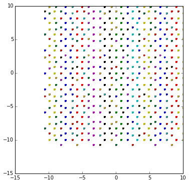

```python
def F(z):
    return np.array([K[t](z) for t in range(4)]).astype(int)

def fList(k):
    return np.sum(k*np.exp(2j*np.pi*np.arange(4)/8), axis=2)

z = np.arange(-5,5,0.01)[...,None] + 1j*np.arange(-5,5,0.01)[None,...]
#print F(z).T
#print
w = fList(F(z).T)

plt.plot(w.real, w.imag, '.')
plt.show()
```

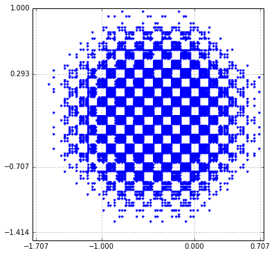

```python
L = 5
dL = 0.1
w1 = np.array([f(F(a + 1j*b))-2*(a+1j*b) for a in np.arange(-L,L+dL,dL) for b in np.arange(-L,L+dL,dL)])


plt.plot(w1.real, w1.imag, '.')
plt.axis("Equal")
plt.grid(True)
plt.xticks([-1-np.sqrt(2)/2, -1, 0, np.sqrt(2)/2])
plt.yticks([1, 1 - np.sqrt(2)/2, - np.sqrt(2)/2, - np.sqrt(2)])
plt.show()
```

```python
# all distinct vertices
pts = np.zeros(1)

for T in w:
    for t in T:
        if not np.any((pts == t)):
            pts = np.hstack((pts,t))
```

```
(-10, 10)
```

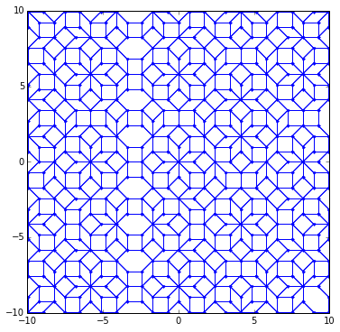

```python
plt.plot(pts.real, pts.imag, '.')

for x in pts:
    for y in pts:
        if(np.abs(x-y) < 1.05 and np.abs(x-y) > 0.95):
            plt.plot([x.real, y.real], [x.imag, y.imag], 'b')

plt.xlim([-10,10])
plt.ylim([-10,10])
```